# Producing plots with ggplot2

Statistical Programming with R

## Packages used

```r
library(ggplot2)
library(mice) # for the boys dataset
library(tidyverse)
library(gridExtra) # to combine plots
```

## Background

## GGplot2

The `ggplot2` package by Hadley Wickham

- produces layered statistical figures.
- uses a “grammar” to build figures component-by-component
- less immediately approachable than base `R` plots but much easier to customize
- a part of the tidyverse

## Documentation

https://ggplot2.tidyverse.org/reference/ is the officil homepage with help files and examples

The book *ggplot2: Elegant Graphics for Data Analysis* by Hadley Wickham is a thorough and concise explanation, and is now available online: https://ggplot2-book.org/index.html

## The Grammar of Graphics

## The Grammar of Graphics

A concept by Leland Wilkinson (2005):

- A grammar of a language defines the rules of structuring words and phrases into meaningful expressions
- A grammar of graphics defines the rules of structuring mathematic and aesthetic elements into a meaningful graph

## Components of a ggplot

- **Data**: which will be displayed on the plot
- **Aesthetic mappings**: How is data mapped to color, size, shape, location…
- **Geometries**: points, lines, shapes…
- **Stats**: stastical transformations - binning, smoothing, quantiles…
- **Scales**: Scales of aesthetic mappings (e.g. Danish=blue, Georgian=red)
- **Coordinate systems**: the plane on which data are mapped on the graphic.
- **Facets**: how should data be split into panels

## Construction of a ggplot

## Construction of a ggplot

Plots are built up in layers, generally in this order:

- Specify the data
- Map variables to aesthetics
- Specify a plot
- Overlay summaries
- Add metadata, annotations

Data must be a dataframe (or tibble). Multiple dataframes can be plotted in the same ggplot

## Example - the `boys` data: scatterplot

Specify the data

```r
ggplot(boys)
```

Map variables to aesthetics

```r
ggplot(boys, aes(x = age, y = bmi))
```

Specify a plot

```r
ggplot(boys, aes(x = age, y = bmi)) +  geom_point()
```

## An example: scatterplot

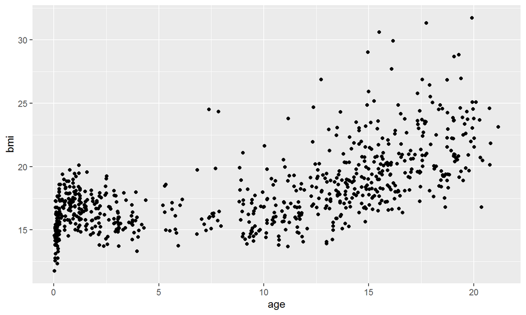

## Layers

New layers can be added to the plot

```r
boys %>%
  filter(!is.na(age) & !is.na(bmi)) %>%
  ggplot(aes(x = age, y = bmi)) +
  geom_point() +
  geom_smooth()
```

## Layers

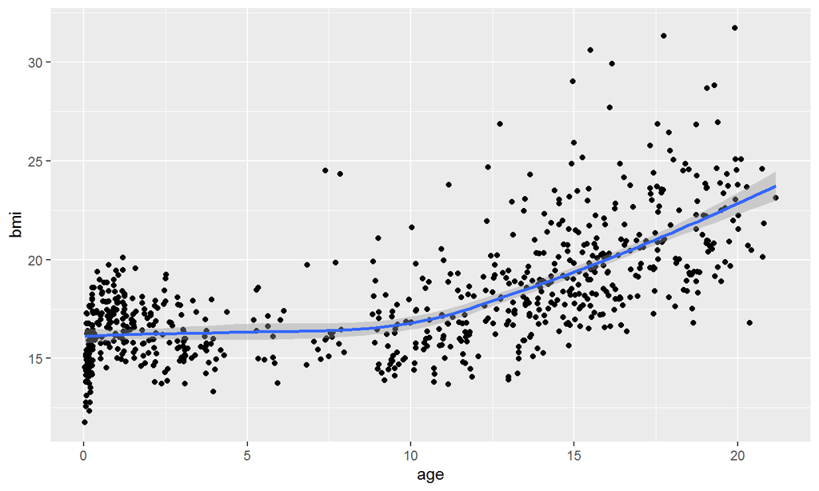

## Aesthetics

- x
- y
- size
- colour
- fill
- opacity (alpha)
- linetype
- …

## Aesthetics

```r
gg <-
  boys %>%
  filter(!is.na(reg)) %>%

  ggplot(aes(x      = age,
             y      = bmi,
             size   = hc,
             colour = reg)) +

  geom_point(alpha = 0.5) +

  labs(title  = "BMI trend for boys",
       x      = "Age",
       y      = "BMI",
       size   = "Head circumference",
       colour = "Region") +
  theme_minimal()
```

## Aesthetics

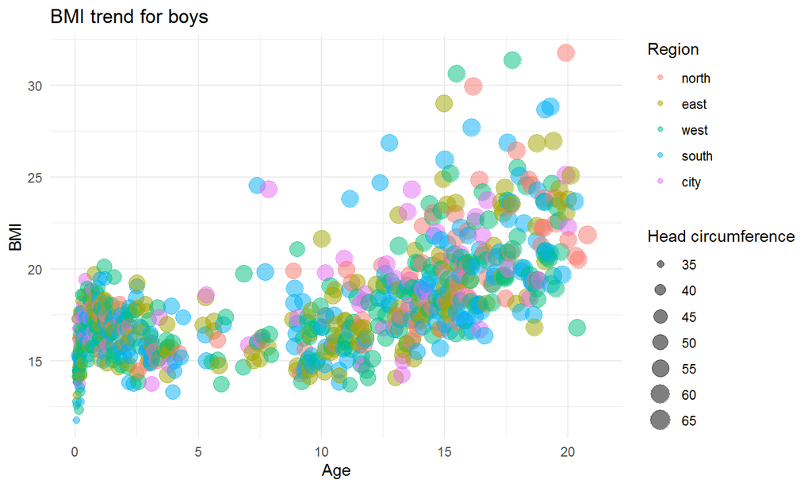

```r
plot(gg)
```

## Aesthetics

Default aesthetics are shared by all layers of the plot. You can do layer-specific aesthetics:

```r
boys %>%
  ggplot( aes(x = age, y = bmi)) +
  geom_point( aes( col = reg )) +
  geom_smooth()
```

## Aesthetics

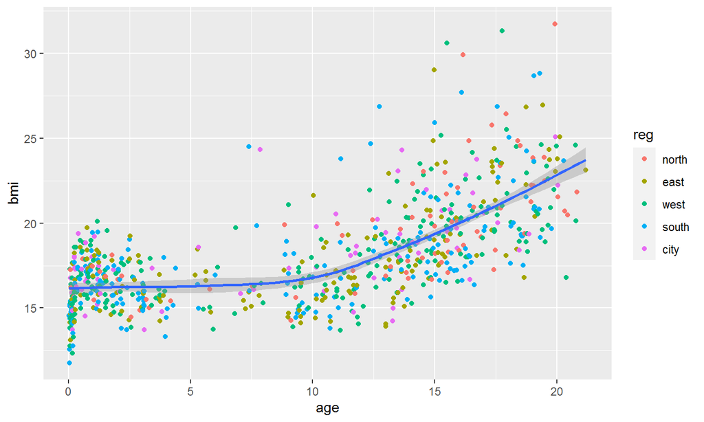

## Mapping vs. setting aesthetics

**Map** variables to aesthetics *inside* the `aes` function, and the aesthetic varies with the variable.

**Set** aesthetics to some constant level *outside* the aes function

```r
boys %>%
  ggplot( aes(x = age, y = bmi)) +
  geom_point( aes( col = reg )) +
  geom_smooth( col = "green")
```

[output not shown]

## Geometries

Geometries are defined in part by which aesthetics they allow and require. You can find information on this in the help file for each geometry

- geom_point
- geom_bar
- geom_line
- geom_smooth
- geom_histogram
- geom_boxplot
- geom_density

## Geoms: Bar

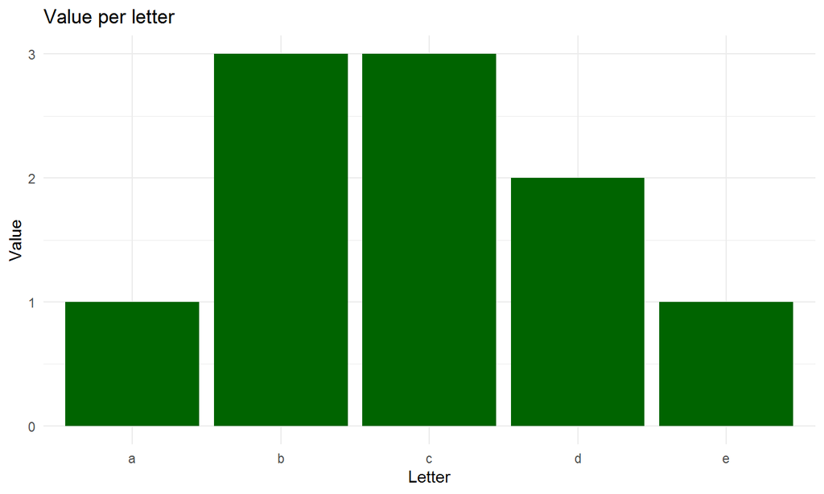

## Geoms: Line

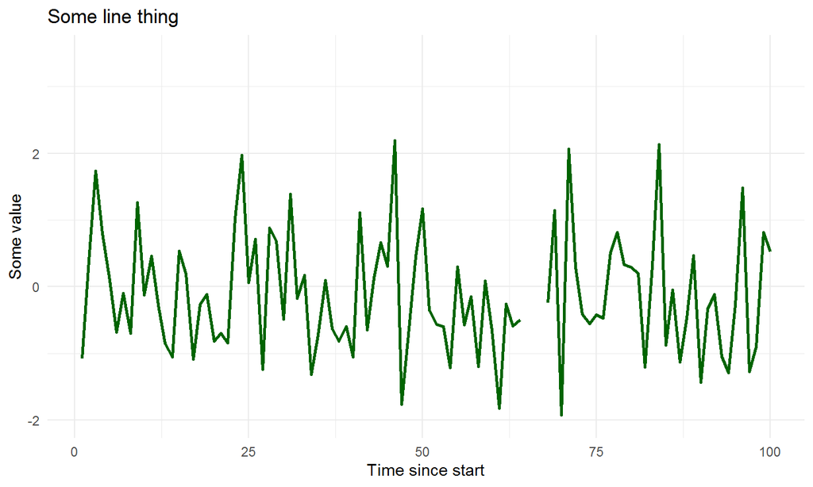

## Geoms: Smooth

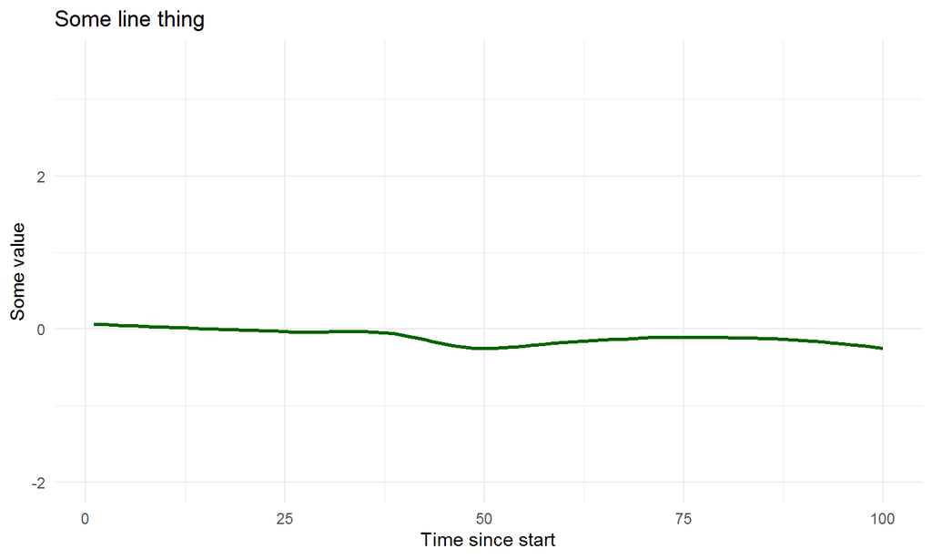

## Geoms: Boxplot

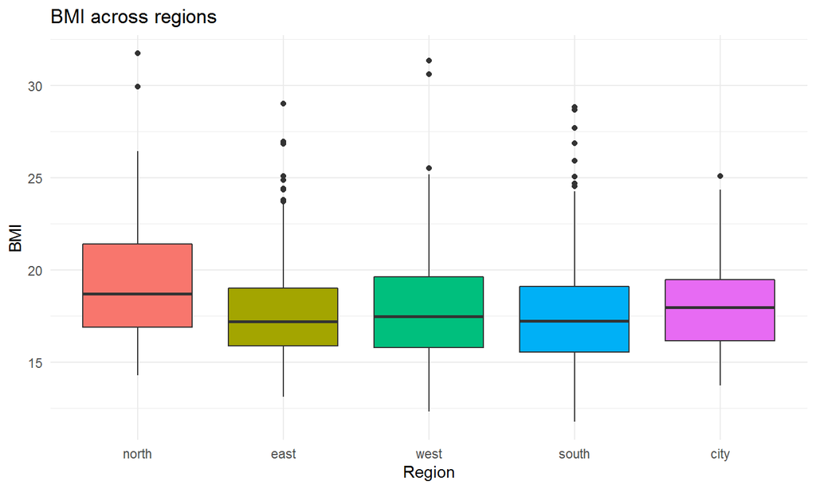

## Stats

Stat functions transform data, for example:

- frequencies of values of a variable (histogram, bar graphs)
- a mean
- a confidence limit

Each stat function has a default geom, so no geom is required for shapes to be rendered. The geom may be respecfied in the stat for different shapes.

## Stats

- `stat_bin` bins the data and by default produces a histogram
- `stat_summary` summarises y at each x (with a mean + se if nothing else is specified) and by default produces a pointrange-plot
- `stat_qq` produces quantile-quantile plots
- …

## Stats

```r
ageplot <- boys %>%
  ggplot( aes( x = age)) +
  stat_bin()

ageplot2 <- boys %>%
  ggplot( aes( x = age)) +
  stat_bin( geom = "line")

grid.arrange( ageplot, ageplot, ncol=2)
```

[output not shown]

## Scales

Scales define which aesthetic values are mapped to data values - eg. if region is mapped to colour, which colour values are used for each region?

`scale_`-functions allow us to control the scales

```r
boys %>%
  ggplot( aes(x = age, y = bmi, shape = reg )) +
  geom_point( ) +
  scale_shape_manual( values = c(5,3,8,13,20))
```

## Scales

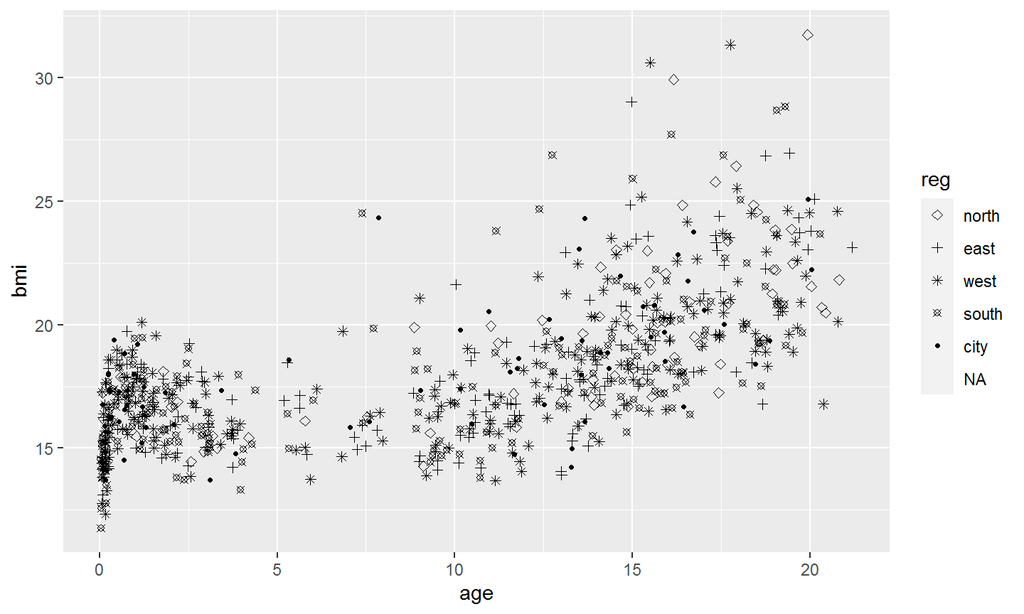

## Colour scale functions

Colour is used a lot, and can be controlled with `scale_col_*`- functions and `scale_fill_*`-functions. For example:

- `scale_fill_hue()`: evenly spaced hues
- `scale_fill_brewer()`: sequential, diverging or qualitative colour schemes, originally intended to display factor levels on a map.
- `scale_fill_viridis_*`: colour maps that are colourblind-friendly and perceptually uniform in both colour and black-and-white

## Colour scale functions

```r
dens <- boys %>%
  mutate( agegrp = case_when( age < 10 ~ "<10",
                              age < 15 ~ "10-14",
                              age >= 15 ~ "15+")) %>%
  ggplot(aes(x=hgt, fill = agegrp))+
  geom_density( alpha=1/3)

grid.arrange( dens, dens + scale_fill_hue(), ncol=2)
```

## Colour scales

[figure not shown]

## Guides

Guides (axes and legends) visualise a scale - The x-axis visualises the mapping of data values to points on the x-axis - The legend tells us which values map to which colours

Guides are displayed by default and can be manipulated with the `guides`-functions. (Eg. `guides(colour="none")` to remove colour-legend)

## Coordinate systems

Nearly always default cartesian, but can be (eg) polar, flipped cartesian, map projections…

## Faceting

Split plots into panels using `facet_wrap` and `facet_grid`

```r
boys %>%
  ggplot( aes(x = age, y = bmi)) +
  geom_point( ) +
  geom_smooth() +
  facet_wrap( ~ reg)
```

## Faceting

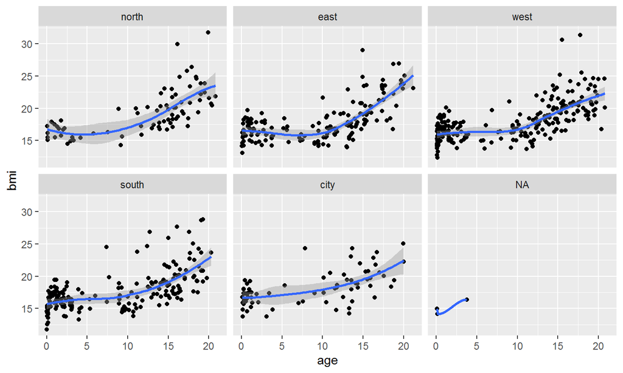

## Themes

Themes control the elements of the graph not related to the data

- Background colour
- Font and font size
- Gridlines
- …

You can apply an existing theme to your plot, or create your own

The `theme` functions allows us to adjust the theme

## Themes

```r
boys %>%
  ggplot( aes(x = age, y = bmi)) +
  geom_point( ) +
  theme( panel.background = element_blank()
       , axis.title.x=element_text( size=14, color="red" ))
```

## Themes

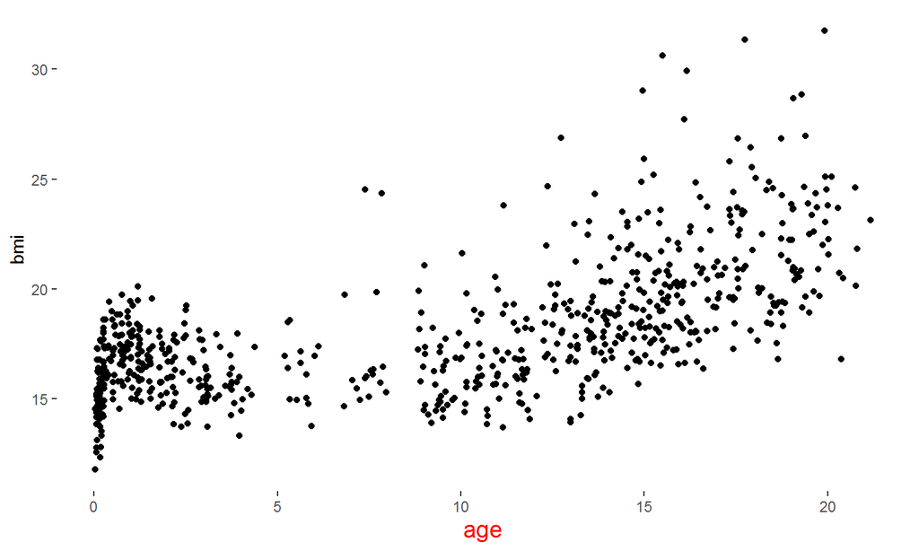

## Saving plots

The `ggsave` functions makes saving plots easy

```r
# Save as pdf
ggsave( "/output/plot.pdf", myplot)

# Save as png and resize
ggsave( "/output/plot.png", myplot, width=7, height=5, units="in")
```